# Instructional Flight Risks Analysis

20 August 2017

## Overview

Commercial flying has become almost a routine activity, but the notion of private flight is still largely considered a risky activity, with flight instruction being classified as the most critical stage.

[figure not shown]

## Overview

This work aims to answer the following questions:

- Do private pilots engage in a **dangerous** and **risky** activity?
- Is the **instruction period more risky** than the posterior flight activities of private pilots?
- Where should the focus be put in order to **improve flight safety** for private pilots?

## Disclaimer

**This presentation is part of the assignments for the class "Building Data Products" of the Johns Hopkins' Data Sciences Specialization on Coursera. Neither the data, nor the findings of this study, should be used as the basis of any further work, as it's sole purpose is merely the familirization with some tools and techniques.**

## The Data Set

- The data set used for this work has been provided by America's authority on air incidents: the [National Transport Security Bureau (NTSB)](https://www.ntsb.gov/_layouts/ntsb.aviation/index.aspx).
- Covers all kind of flights (Commercial, Instruction, Military) in all contries that NTSB has performed investigations at.
- For this analysis, data will be filtered between 1st Jan 2000 and 31st December 2015, resulting in a total of **13153 observations**, out of which **1657** are **instructional flights**.

## Is It Dangerous?

No.

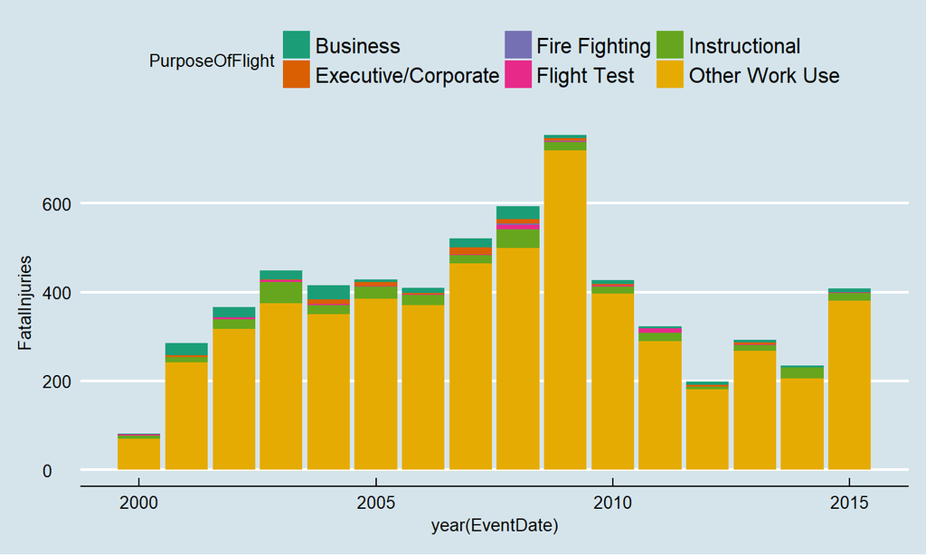

## Geographical Analysis

[interactive chart not shown]

## Summary

This short analysis on the data available was meant to prove flight instruction is no more dangerous than other activities such as *extreme gardening* or *bare-handed bird watching*. However, lack of time on the author meant that the study could not be finalized as expected. However, the author would like to encourage everyone to experience the joys of flying, and the learning process involved.

Good landings!